# Time Series Analysis

Freddie Zhang  
Mar. 10, 2019

```python
# Import packages
import os
import sys
import fbprophet
import datetime
import holidays
import numpy as np
import pandas as pd
import seaborn as sns
import matplotlib.dates as mdates
import matplotlib.pyplot as pyplot
from datetime import date
from statistics import mode
from fbprophet import Prophet
from fbprophet.diagnostics import cross_validation
from fbprophet.diagnostics import performance_metrics
from matplotlib import pyplot as plt
from statsmodels.tsa import seasonal
from statsmodels.tsa import stattools
from search_sampler import SearchSampler
from pandas.plotting import autocorrelation_plot
from sklearn.model_selection import train_test_split
from sklearn.linear_model import LassoLarsCV
from sklearn.metrics import mean_squared_error
from sklearn.preprocessing import MinMaxScaler
from sklearn.metrics import r2_score
import warnings
warnings.filterwarnings('ignore')
```

### Section 0. Brand Information

Brand: Netflix  
Freebase ID: /m/017rf_  
Source: https://www.wikidata.org

### Section 1. Decompose a Time Series: Google Trends & Non-stationary data

In section 1, I

```python
# Read in Netflix_googletrends.csv as a DataFrame
Netflix = pd.read_csv('Netflix.googletrends.csv',parse_dates=['period'])
# Convert column of 'period' into DateTime format.
Netflix['period'] = Netflix['period'].dt.date
```

```python
# Set the column of 'period' as the index of DataFrame.
Netflix.set_index('period',inplace=True)
```

```python
# Have a glance
Netflix.head(5)
```

| period | Unnamed: 0 | date | value | onediffvalue |
| --- | --- | --- | --- | --- |
| 2013-10-07 | 0 | Oct 07 2013 | 20979.550508 | NaN |
| 2013-10-08 | 1 | Oct 08 2013 | 19372.317342 | -1607.233166 |
| 2013-10-09 | 2 | Oct 09 2013 | 19643.282124 | 270.964782 |
| 2013-10-10 | 3 | Oct 10 2013 | 19588.818874 | -54.463250 |
| 2013-10-11 | 4 | Oct 11 2013 | 20986.168158 | 1397.349284 |

```python
'''
Convert data to a stationary format that is acceptable for time series modeling by using
YearLocator() and MonthLocator() from matplotlib.dates library.
'''
years = mdates.YearLocator() # Locate years by matplotlib.dates
months = mdates.MonthLocator() # Locate months by matplotlib.dates
yearmonth = mdates.DateFormatter('%m,%y') # Format Data to mm,yy
```

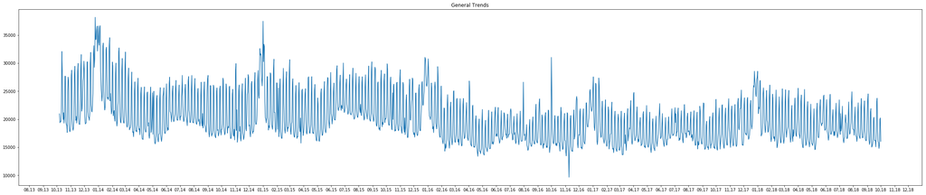

```python
# Plot of General Trends (Moving Averages)
fig, ax = pyplot.subplots(figsize=(40,8))

ax.xaxis.set_major_locator(months)
ax.xaxis.set_major_formatter(yearmonth)
ax.title.set_text('General Trends')
ax.plot(Netflix.index,Netflix['value'])

plt.show()
```

```python
'''
Decomposing the time series by using 'seasonal.seasonal_decompose' from 'statsmodels.tsa'
library.
'''
decompose_model = seasonal.seasonal_decompose(Netflix['value'].tolist(), freq=365, model='additive')
dir(decompose_model)
```

```
['__class__',
 '__delattr__',
 '__dict__',
 '__dir__',
 '__doc__',
 '__eq__',
 '__format__',
 '__ge__',
 '__getattribute__',
 '__gt__',
 '__hash__',
 '__init__',
 '__init_subclass__',
 '__le__',
 '__lt__',
 '__module__',
 '__ne__',
 '__new__',
 '__reduce__',
 '__reduce_ex__',
 '__repr__',
 '__setattr__',
 '__sizeof__',
 '__str__',
 '__subclasshook__',
 '__weakref__',
 'nobs',
 'observed',
 'plot',
 'resid',
 'seasonal',
 'trend']
```

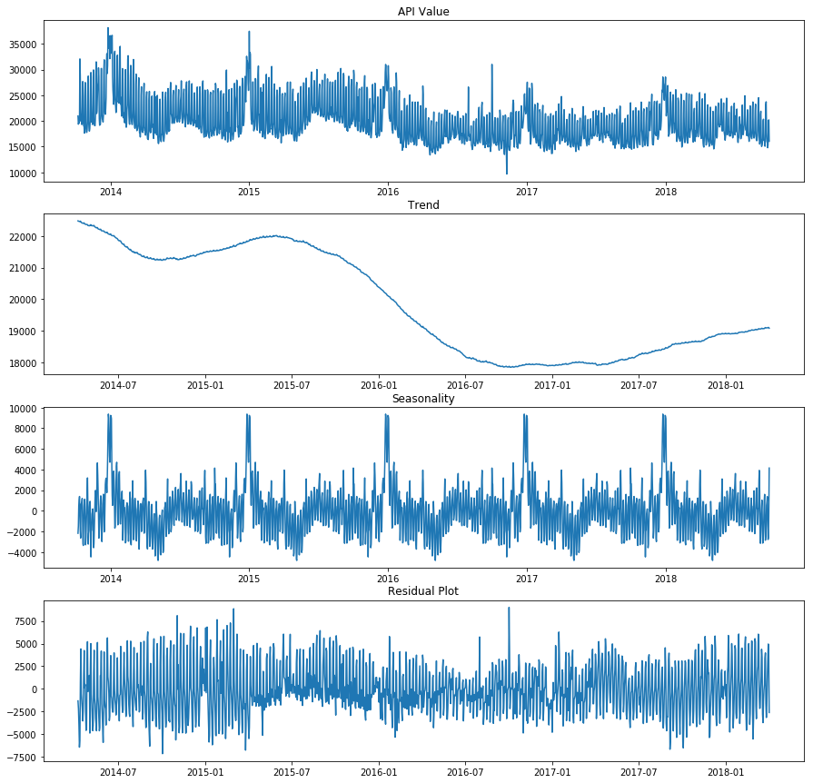

```python
'''
A standard time series equation can be expressed as $x_t = f_t + s_t + c_t + e_t$, which
is a sum of the trend, seasonal, cyclical, and irregular components in that order.
Plot of 'API Value', 'Trend', 'Seasonality', 'Residual' versus time.
'''
fig, (ax1, ax2, ax3, ax4) = pyplot.subplots(4, figsize=(15,15))

ax1.plot(Netflix.index, Netflix['value'])
ax2.plot(Netflix.index, decompose_model.trend)
ax3.plot(Netflix.index, decompose_model.seasonal)
ax4.plot(Netflix.index, decompose_model.resid)

ax1.title.set_text('API Value')
ax2.title.set_text('Trend')
ax3.title.set_text('Seasonality')
ax4.title.set_text('Residual Plot')

plt.show()
```

**What is the overall trend? Is the search interest for your brand steadily growing?**

For a more comprehensive analysis, we could break the timeline to only one year to avoid short-run effects.

**What does the seasonality look like for this brand?**

The seasonality plot shows that Netflix arrives at its maximum search interest at the beginning and end of each year. We could also observe another little peak around summer period. Seasonality is driven by the consumers because the search interest of Netflix depends on the spare time of consumers.

```python
# Add a new column of 'seasonal' component from decompose_model into the dataframe.
Netflix['seasonal'] = decompose_model.seasonal
# Have a glance
Netflix.head(5)
```

| period | Unnamed: 0 | date | value | onediffvalue | seasonal |
| --- | --- | --- | --- | --- | --- |
| 2013-10-07 | 0 | Oct 07 2013 | 20979.550508 | NaN | -2179.300695 |
| 2013-10-08 | 1 | Oct 08 2013 | 19372.317342 | -1607.233166 | -1482.657901 |
| 2013-10-09 | 2 | Oct 09 2013 | 19643.282124 | 270.964782 | 466.350198 |
| 2013-10-10 | 3 | Oct 10 2013 | 19588.818874 | -54.463250 | 1031.644542 |
| 2013-10-11 | 4 | Oct 11 2013 | 20986.168158 | 1397.349284 | 1388.189943 |

```python
# Start analyzing the seasonality trend in relatively short run, one-year range.
startdate = pd.to_datetime("2015-01-01").date()
enddate = pd.to_datetime("2015-12-31").date()
oneyear = Netflix.loc[startdate:enddate]
```

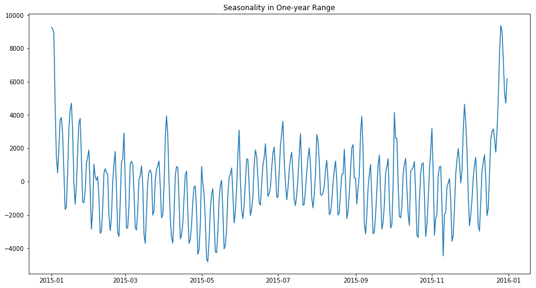

```python
# Plot of Seasonality in 2015
fig, ax = pyplot.subplots(figsize=(15,8))

pyplot.plot(oneyear.index, oneyear.seasonal)
ax.title.set_text('Seasonality in One-year Range')

plt.show()
```

The plot above shows the seasonality in the one-year range. With a more clear insight, we could observe the Google search interest arrives at its peak at the beginning and end of the year. Moreover, the search interest starts decreasing from January to May and warms up a little bit during the summer. The search interest is unstable from September to November and starts climbing in December.

### Section 2. Facebook Prophet for Forecasting

In section 2, I

1. fitted the model and graph a residual plot to test the accuracy of the model by using [Facebook's Prophet forecasting tool](https://facebook.github.io/prophet/).
2. created a forecast for the next year's google's search interest by using the same toll and create a graph of the forecast

```python
Netflix = pd.read_csv('Netflix.googletrends.csv',parse_dates=['period'])
prophetdataframe = pd.DataFrame() # Create a new prophet
prophetdataframe['ds'] = Netflix['period'] # DataStamp
prophetdataframe['y'] = Netflix['value'] # Value
```

```python
# Have a glance
prophetdataframe.head(5)
```

|  | ds | y |
| --- | --- | --- |
| 0 | 2013-10-07 | 20979.550508 |
| 1 | 2013-10-08 | 19372.317342 |
| 2 | 2013-10-09 | 19643.282124 |
| 3 | 2013-10-10 | 19588.818874 |
| 4 | 2013-10-11 | 20986.168158 |

```python
# Fit the model by fbprophet.
m = Prophet()
m.fit(prophetdataframe)
```

```
INFO:fbprophet:Disabling daily seasonality. Run prophet with daily_seasonality=True to override this.
```

```
<fbprophet.forecaster.Prophet at 0x1c31b45048>
```

```python
# Create a new dataframe for next one year with dates
future = m.make_future_dataframe(periods = 365)
# Have a glance
future.tail()
```

|  | ds |
| --- | --- |
| 2181 | 2019-09-27 |
| 2182 | 2019-09-28 |
| 2183 | 2019-09-29 |
| 2184 | 2019-09-30 |
| 2185 | 2019-10-01 |

```python
'''
New DataFrame generated by the prediction from fbprophet, including columns of trend, yhat,
additive terms, weekly, yearly, multiplicative terms(empty) and their ranges.
'''
forecast = m.predict(future)
forecast.tail()
```

|  | ds | trend | yhat_lower | yhat_upper | trend_lower | trend_upper | additive_terms | additive_terms_lower | additive_terms_upper | weekly | weekly_lower | weekly_upper | yearly | yearly_lower | yearly_upper | multiplicative_terms | multiplicative_terms_lower | multiplicative_terms_upper | yhat |
| --- | --- | --- | --- | --- | --- | --- | --- | --- | --- | --- | --- | --- | --- | --- | --- | --- | --- | --- | --- |
| 2181 | 2019-09-27 | 20369.812455 | 15281.410259 | 21145.725617 | 18735.467006 | 22241.341869 | -2305.527187 | -2305.527187 | -2305.527187 | -1162.812517 | -1162.812517 | -1162.812517 | -1142.714670 | -1142.714670 | -1142.714670 | 0.0 | 0.0 | 0.0 | 18064.285268 |
| 2182 | 2019-09-28 | 20372.361037 | 20346.334021 | 26219.796783 | 18730.608963 | 22254.719438 | 2793.341771 | 2793.341771 | 2793.341771 | 3854.264822 | 3854.264822 | 3854.264822 | -1060.923052 | -1060.923052 | -1060.923052 | 0.0 | 0.0 | 0.0 | 23165.702808 |
| 2183 | 2019-09-29 | 20374.909620 | 21572.735124 | 27440.054563 | 18725.346779 | 22267.311382 | 4013.627179 | 4013.627179 | 4013.627179 | 4980.858450 | 4980.858450 | 4980.858450 | -967.231271 | -967.231271 | -967.231271 | 0.0 | 0.0 | 0.0 | 24388.536800 |
| 2184 | 2019-09-30 | 20377.458203 | 15728.690127 | 21758.448491 | 18719.614868 | 22278.190239 | -1717.283273 | -1717.283273 | -1717.283273 | -853.269562 | -853.269562 | -853.269562 | -864.013712 | -864.013712 | -864.013712 | 0.0 | 0.0 | 0.0 | 18660.174930 |
| 2185 | 2019-10-01 | 20380.006786 | 14524.255804 | 20542.918715 | 18713.882957 | 22287.666294 | -2927.161767 | -2927.161767 | -2927.161767 | -2173.206551 | -2173.206551 | -2173.206551 | -753.955217 | -753.955217 | -753.955217 | 0.0 | 0.0 | 0.0 | 17452.845018 |

```python
# Model Diagnostics
erroranalytics = m.predict(prophetdataframe)
erroranalytics['value'] = prophetdataframe['y'] # import real value
erroranalytics['residuals'] = erroranalytics['value'] - erroranalytics['yhat'] # compare predict value to real value
erroranalytics['absoluteresiduals'] = abs(erroranalytics['residuals']) # absolute error
# Have a glance
erroranalytics.head()
```

|  | ds | trend | yhat_lower | yhat_upper | trend_lower | trend_upper | additive_terms | additive_terms_lower | additive_terms_upper | weekly | ... | yearly | yearly_lower | yearly_upper | multiplicative_terms | multiplicative_terms_lower | multiplicative_terms_upper | yhat | value | residuals | absoluteresiduals |
| --- | --- | --- | --- | --- | --- | --- | --- | --- | --- | --- | --- | --- | --- | --- | --- | --- | --- | --- | --- | --- | --- |
| 0 | 2013-10-07 | 24253.506485 | 21039.075364 | 25672.945075 | 24253.506485 | 24253.506485 | -935.867106 | -935.867106 | -935.867106 | -853.269562 | ... | -82.597544 | -82.597544 | -82.597544 | 0.0 | 0.0 | 0.0 | 23317.639379 | 20979.550508 | -2338.088871 | 2338.088871 |
| 1 | 2013-10-08 | 24243.191682 | 19864.427188 | 24467.541027 | 24243.191682 | 24243.191682 | -2191.201605 | -2191.201605 | -2191.201605 | -2173.206551 | ... | -17.995054 | -17.995054 | -17.995054 | 0.0 | 0.0 | 0.0 | 22051.990078 | 19372.317342 | -2679.672736 | 2679.672736 |
| 2 | 2013-10-09 | 24232.876879 | 19661.510384 | 24186.239106 | 24232.876879 | 24232.876879 | -2304.887576 | -2304.887576 | -2304.887576 | -2334.001433 | ... | 29.113856 | 29.113856 | 29.113856 | 0.0 | 0.0 | 0.0 | 21927.989303 | 19643.282124 | -2284.707179 | 2284.707179 |
| 3 | 2013-10-10 | 24222.562077 | 19624.441298 | 24288.204168 | 24222.562077 | 24222.562077 | -2254.781087 | -2254.781087 | -2254.781087 | -2311.833210 | ... | 57.052123 | 57.052123 | 57.052123 | 0.0 | 0.0 | 0.0 | 21967.780990 | 19588.818874 | -2378.962116 | 2378.962116 |
| 4 | 2013-10-11 | 24212.247274 | 20864.271577 | 25378.721595 | 24212.247274 | 24212.247274 | -1098.177716 | -1098.177716 | -1098.177716 | -1162.812517 | ... | 64.634801 | 64.634801 | 64.634801 | 0.0 | 0.0 | 0.0 | 23114.069557 | 20986.168158 | -2127.901400 | 2127.901400 |

5 rows × 22 columns

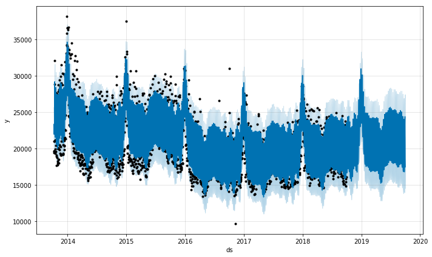

```python
# Visualization
fig1 = m.plot(forecast)
```

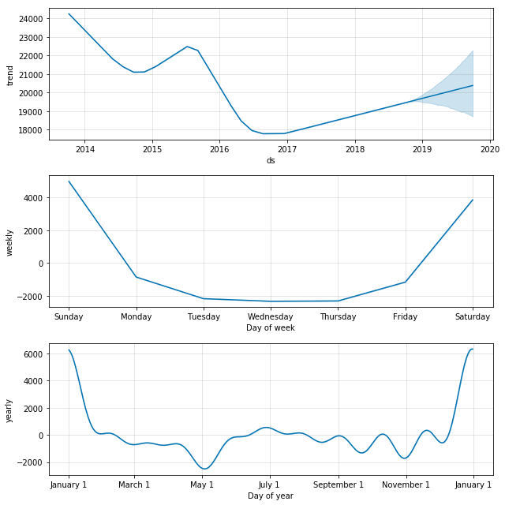

```python
# component visualizations
fig2 = m.plot_components(forecast)
```

```python
# sum of absolute residuals
totalerror = erroranalytics['absoluteresiduals'].sum()
```

```python
print(totalerror)
```

```
2363300.1076838253
```

```python
# MAE
print(totalerror/len(erroranalytics))
# Meaning: the model was off about 1300 Google trend units every day on average.
```

```
1297.8034638571253
```

```python
erroranalytics['value'].describe()
```

```
count     1821.000000
mean     20097.461182
std       4249.942089
min       9673.065405
25%      16888.614395
50%      19093.643513
75%      22227.758983
max      38175.606745
Name: value, dtype: float64
```

### Section 2.1 Create a forecast using holiday effects

```python
goodholidays = [] # new list for holidays
for date, name in sorted(holidays.US(years=2014).items()): # take an example of 2014
    goodholidays.append(name)
    print(date, name)
```

```
2014-01-01 New Year's Day
2014-01-20 Martin Luther King, Jr. Day
2014-02-17 Washington's Birthday
2014-05-26 Memorial Day
2014-07-04 Independence Day
2014-09-01 Labor Day
2014-10-13 Columbus Day
2014-11-11 Veterans Day
2014-11-27 Thanksgiving
2014-12-25 Christmas Day
```

```python
# new DataFrame
sales = pd.DataFrame(columns=['holiday','ds','lower_window','upper_window'])
```

```python
for year in range(2014,2021): # major holidays from 2014 to 2020
    for date, name in sorted(holidays.US(years=year).items()):
        lower_window = 0 # reset the 'lower_window'
        upper_window = 0 # reset the 'upper_window'
        if name in goodholidays:
            dayofweek = date.weekday()
        #add additional dates to current holidays
            if name == "New Year's Day":
                lower_window = -1
            if name == "Thanksgiving":
                upper_window = 3
            if name == "Christmas Day":
                lower_window = -5
                upper_window = 6
            if name == "Labor Day":
                lower_window = -3
            if name == "Independence Day":
                upper_window = 3
            sales.loc[len(sales)] = [name, date, lower_window, upper_window]
```

```python
'''
Add include Superbowl as a typical holiday. Live stream on Netflix for sure!
'''
superbowls = pd.DataFrame({
  'holiday': 'Superbowl',
  'ds': pd.to_datetime(['2014-02-02', '2015-02-01', '2016-02-07',
                       '2017-02-05', '2018-02-04', '2019-02-03',
                       '2020-02-02']),
  'lower_window': 0,
  'upper_window': 1,
})
```

```python
superbowls['ds'] = superbowls['ds'].dt.date
```

```python
sales = pd.concat([sales, superbowls],ignore_index=True)
```

```python
sales = sales.sort_values(['ds'], ascending=[True]).reset_index(drop=True)
# Have a glance
sales.head()
```

|  | holiday | ds | lower_window | upper_window |
| --- | --- | --- | --- | --- |
| 0 | New Year's Day | 2014-01-01 | -1 | 0 |
| 1 | Martin Luther King, Jr. Day | 2014-01-20 | 0 | 0 |
| 2 | Superbowl | 2014-02-02 | 0 | 1 |
| 3 | Washington's Birthday | 2014-02-17 | 0 | 0 |
| 4 | Memorial Day | 2014-05-26 | 0 | 0 |

```python
adv_prophetdataframe = pd.DataFrame()
adv_prophetdataframe['ds'] = Netflix['period']
adv_prophetdataframe['y'] = Netflix['value']
adv_prophetdataframe.head()
```

|  | ds | y |
| --- | --- | --- |
| 0 | 2013-10-07 | 20979.550508 |
| 1 | 2013-10-08 | 19372.317342 |
| 2 | 2013-10-09 | 19643.282124 |
| 3 | 2013-10-10 | 19588.818874 |
| 4 | 2013-10-11 | 20986.168158 |

```python
adv_m = Prophet(holidays=sales)
adv_m.add_country_holidays(country_name='US')
adv_m.fit(adv_prophetdataframe)
# add Netflix up a show time
```

```
INFO:fbprophet:Disabling daily seasonality. Run prophet with daily_seasonality=True to override this.
```

```
<fbprophet.forecaster.Prophet at 0x1c3035b898>
```

```python
print(adv_m.train_holiday_names)
```

```
0                  New Year's Day
1     Martin Luther King, Jr. Day
2                       Superbowl
3           Washington's Birthday
4                    Memorial Day
5                Independence Day
6                       Labor Day
7                    Columbus Day
8                    Veterans Day
9                    Thanksgiving
10                  Christmas Day
11       Christmas Day (Observed)
12      New Year's Day (Observed)
13        Veterans Day (Observed)
14    Independence Day (Observed)
dtype: object
```

```python
'''
Create new DataFrame for prediction on next one year
'''
adv_future = adv_m.make_future_dataframe(periods = 365)
adv_forecast = adv_m.predict(adv_future)
```

```python
adv_erroranalytics = adv_m.predict(adv_prophetdataframe)
adv_erroranalytics['value'] = adv_prophetdataframe['y']
adv_erroranalytics['residuals'] = adv_erroranalytics['value'] - adv_erroranalytics['yhat']
adv_erroranalytics['absoluteresiduals'] = abs(adv_erroranalytics['residuals'])
adv_erroranalytics.head()
```

|  | ds | trend | yhat_lower | yhat_upper | trend_lower | trend_upper | Christmas Day | Christmas Day_lower | Christmas Day_upper | Christmas Day (Observed) | ... | yearly | yearly_lower | yearly_upper | multiplicative_terms | multiplicative_terms_lower | multiplicative_terms_upper | yhat | value | residuals | absoluteresiduals |
| --- | --- | --- | --- | --- | --- | --- | --- | --- | --- | --- | --- | --- | --- | --- | --- | --- | --- | --- | --- | --- | --- |
| 0 | 2013-10-07 | 24236.365093 | 20907.321575 | 25062.675489 | 24236.365093 | 24236.365093 | 0.0 | 0.0 | 0.0 | 0.0 | ... | 28.781891 | 28.781891 | 28.781891 | 0.0 | 0.0 | 0.0 | 23111.483470 | 20979.550508 | -2131.932961 | 2131.932961 |
| 1 | 2013-10-08 | 24225.796741 | 20278.063695 | 24154.509700 | 24225.796741 | 24225.796741 | 0.0 | 0.0 | 0.0 | 0.0 | ... | 56.151747 | 56.151747 | 56.151747 | 0.0 | 0.0 | 0.0 | 22202.049520 | 19372.317342 | -2829.732178 | 2829.732178 |
| 2 | 2013-10-09 | 24215.228388 | 20062.796087 | 23876.912388 | 24215.228388 | 24215.228388 | 0.0 | 0.0 | 0.0 | 0.0 | ... | 68.460592 | 68.460592 | 68.460592 | 0.0 | 0.0 | 0.0 | 22040.139980 | 19643.282124 | -2396.857856 | 2396.857856 |
| 3 | 2013-10-10 | 24204.660036 | 19894.285164 | 24003.722991 | 24204.660036 | 24204.660036 | 0.0 | 0.0 | 0.0 | 0.0 | ... | 65.206428 | 65.206428 | 65.206428 | 0.0 | 0.0 | 0.0 | 21950.387871 | 19588.818874 | -2361.568997 | 2361.568997 |
| 4 | 2013-10-11 | 24194.091683 | 21008.293163 | 25021.448389 | 24194.091683 | 24194.091683 | 0.0 | 0.0 | 0.0 | 0.0 | ... | 46.269666 | 46.269666 | 46.269666 | 0.0 | 0.0 | 0.0 | 23039.317894 | 20986.168158 | -2053.149737 | 2053.149737 |

5 rows × 70 columns

```python
adv_totalerror = adv_erroranalytics['absoluteresiduals'].sum()
```

```python
print(adv_totalerror)
```

```
2053497.7449622154
```

```python
print(adv_totalerror/len(adv_erroranalytics))
```

```
1127.675862142897
```

**How accurate does the model appear to be?**

The accuracy of the model is representing by the average prediction error. Lower average prediction error indicates a higher accuracy in general. In this case, the forecast using holiday effects has a lower average prediction error (1127.7 compared with 1297.8) and is more accurate in our case.

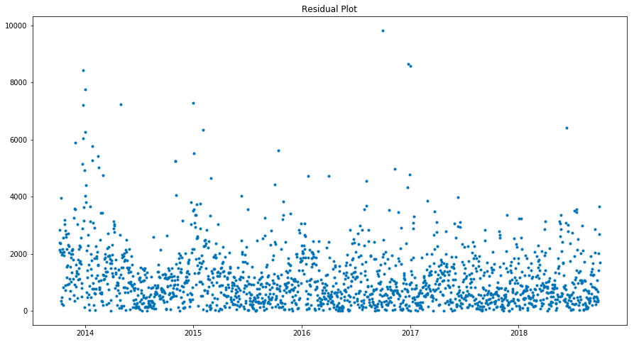

```python
fig, ax = pyplot.subplots(figsize=(15,8))

ax.plot(adv_erroranalytics['ds'].dt.to_pydatetime(), adv_erroranalytics['absoluteresiduals'], 'k.', color='#0072B2')
ax.title.set_text('Residual Plot')

plt.show()
```

**Are the residuals consistent across time? If not, why do you think it varies?**

Based on the residual plot above, we could find that the residuals are not consistent across time. The residuals tend to be larger at the beginning and end of each year while is it is similar on other occasions. I think the residuals are varied because of some holidays effects and outliers effect. Even though we have included holidays effect in our forecasting, the difference in search interest is still too significant to be minimized.

### Section 3. Forecast Next Year's Google's Search Interest

In section 3, I

1. used the tool to forecast next year's google's search interest.
2. created a graph of the forecast

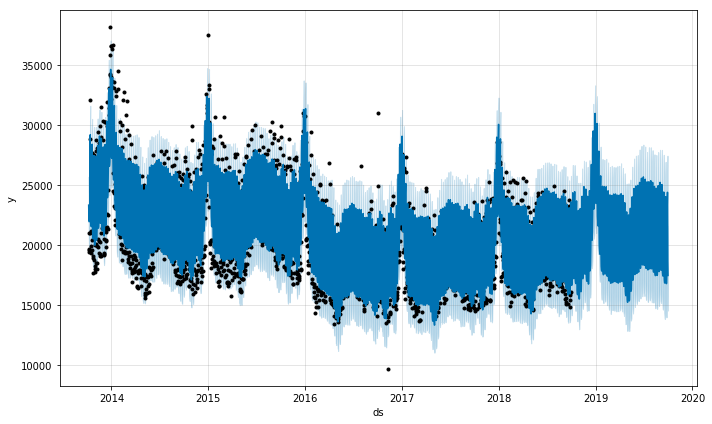

```python
# create forecast plot
fig1 = m.plot(forecast)
```

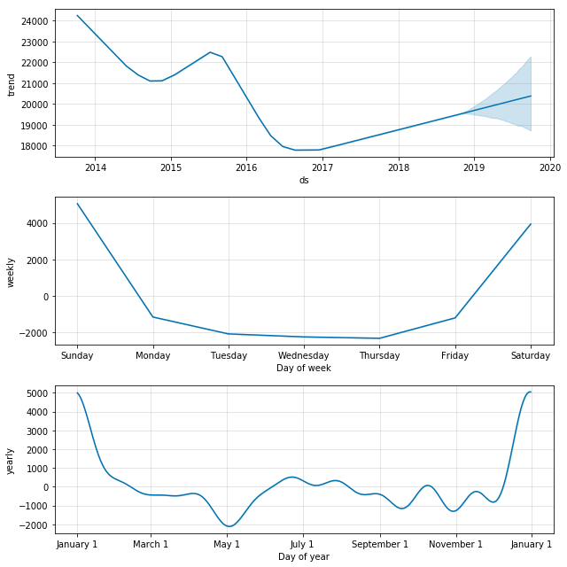

```python
# create component plot
fig2 = adv_m.plot_components(forecast)
```

**What are the projected high interest times?**

Based on the weekly plot, we could find Sunday and Saturday are the times that Google search interests of Netflix are high. The yearly plot also indicates that January is the time that the search interests are high. These projected high-interest times indicate consumers tend to have more free time during the weekends and New Year to watch Netflix. Since some people might have a summer break, we could also observe summer as a relatively active search time.

**What are the projected low interest times?**

From the same graph, we could observe search interests decrease significantly from Monday and remain low from Tuesday to Thursday. The search interests would increase again from Friday and stay high during the weekend. In the annual aspect, May tends to have the lowest search interests. The search interests decrease from January to February and keep variating from September to November. These patterns indicate consumers are busy during the weekdays and have less time watching Netflix. Also, people are super busy before some big holidays.

### Part 4. Advertising Expenditure Data & Granger Causality

In section 4, I

1. used the adspend data of Netflix and used it the expenditure time series as possible predictors
2. analyzed whether advertising expenditures drive Google search interest

### Section 4.1 Preprocessing AdSpend Data

```python
# load adspend data
adspend = pd.read_csv('netflix.adspend.csv', encoding="ISO-8859-1")
```

```python
# perform data cleaning
adspend['TIME PERIOD'] = adspend['TIME PERIOD'].str.replace("WEEK OF ","",regex=True)
adspend['TIME PERIOD'] = adspend['TIME PERIOD'].str.replace(" \(B\)", "",regex=True)
adspend.columns = adspend.columns.str.replace(" DOLS \(000\)", "",regex=True)
```

```python
# Ignore the last 5 rows to avoid NA.
adspend = adspend[:-5]
```

```python
adspend.tail()
```

|  | TIME PERIOD | PRODUCT | TOTAL | NETWORK TV | CABLE TV | SYNDICATION | SPOT TV | MAGAZINES | SUNDAY MAGS | NATL NEWSP | NEWSPAPER | NETWORK RADIO | NAT SPOT RADIO | OUTDOOR |
| --- | --- | --- | --- | --- | --- | --- | --- | --- | --- | --- | --- | --- | --- | --- |
| 1759 | OCT 01, 2018 | Netflix-Maniac : Online | 31.2 | 0.0 | 0.0 | 0.0 | 0.0 | 0.0 | 0.0 | 0.0 | 0.0 | 0.0 | 0.0 | 31.2 |
| 1760 | OCT 01, 2018 | Netflix-Private Life : Online | 421.2 | 0.0 | 0.0 | 0.0 | 16.1 | 93.5 | 0.0 | 293.6 | 18.1 | 0.0 | 0.0 | 0.0 |
| 1761 | OCT 01, 2018 | Netflix-Quincy : Online | 172.9 | 0.0 | 0.0 | 0.0 | 0.0 | 172.9 | 0.0 | 0.0 | 0.0 | 0.0 | 0.0 | 0.0 |
| 1762 | OCT 01, 2018 | Netflix-Super Monsters : Online | 2.3 | 0.0 | 2.3 | 0.0 | 0.0 | 0.0 | 0.0 | 0.0 | 0.0 | 0.0 | 0.0 | 0.0 |
| 1763 | OCT 01, 2018 | Private Life : Movie | 27.2 | 0.0 | 0.0 | 0.0 | 27.2 | 0.0 | 0.0 | 0.0 | 0.0 | 0.0 | 0.0 | 0.0 |

```python
# display all the columns names
list(adspend)
```

```
['TIME PERIOD',
 'PRODUCT',
 'TOTAL',
 'NETWORK TV',
 'CABLE TV',
 'SYNDICATION',
 'SPOT TV',
 'MAGAZINES',
 'SUNDAY MAGS',
 'NATL NEWSP',
 'NEWSPAPER',
 'NETWORK RADIO',
 'NAT SPOT RADIO',
 'OUTDOOR']
```

```python
# convert time period to datetime formate.
adspend['FIXED TIME'] = pd.to_datetime(adspend['TIME PERIOD'])
```

```python
# aggregated the total ads spend by time
adspendnoproducts = adspend.pivot_table(index = 'FIXED TIME', aggfunc = np.sum)
```

```python
adspendnoproducts.head()
```

| FIXED TIME | CABLE TV | MAGAZINES | NAT SPOT RADIO | NATL NEWSP | NETWORK RADIO | NETWORK TV | NEWSPAPER | OUTDOOR | SPOT TV | SUNDAY MAGS | SYNDICATION | TOTAL |
| --- | --- | --- | --- | --- | --- | --- | --- | --- | --- | --- | --- | --- |
| 2013-10-07 | 54.6 | 0.0 | 0.0 | 0.0 | 0.0 | 222.9 | 0.0 | 0.0 | 19.8 | 0.0 | 263.2 | 560.5 |
| 2013-10-14 | 21.3 | 0.0 | 0.0 | 0.0 | 0.0 | 117.2 | 0.0 | 0.0 | 9.7 | 0.0 | 413.5 | 561.7 |
| 2013-10-21 | 14.1 | 0.0 | 0.0 | 0.0 | 0.0 | 145.8 | 0.0 | 0.0 | 10.3 | 0.0 | 279.1 | 449.3 |
| 2013-10-28 | 3.7 | 0.0 | 0.0 | 0.0 | 0.0 | 44.7 | 0.0 | 233.0 | 21.5 | 0.0 | 326.1 | 629.1 |
| 2013-11-04 | 13.0 | 0.0 | 0.0 | 0.0 | 0.0 | 175.9 | 0.0 | 0.0 | 15.1 | 0.0 | 215.3 | 419.3 |

```python
list(adspendnoproducts)
```

```
['CABLE TV',
 'MAGAZINES',
 'NAT SPOT RADIO',
 'NATL NEWSP',
 'NETWORK RADIO',
 'NETWORK TV',
 'NEWSPAPER',
 'OUTDOOR',
 'SPOT TV',
 'SUNDAY MAGS',
 'SYNDICATION',
 'TOTAL']
```

```python
adspendnoproducts.index
```

```
DatetimeIndex(['2013-10-07', '2013-10-14', '2013-10-21', '2013-10-28',
               '2013-11-04', '2013-11-11', '2013-11-18', '2013-11-25',
               '2013-12-02', '2013-12-09',
               ...
               '2018-07-30', '2018-08-06', '2018-08-13', '2018-08-20',
               '2018-08-27', '2018-09-03', '2018-09-10', '2018-09-17',
               '2018-09-24', '2018-10-01'],
              dtype='datetime64[ns]', name='FIXED TIME', length=261, freq=None)
```

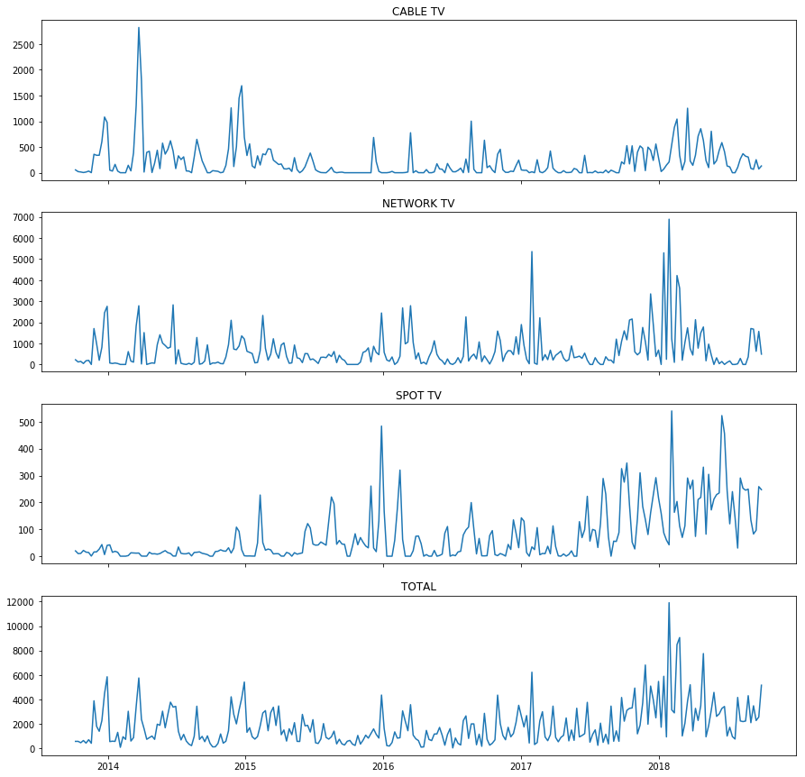

```python
# plot total ads spend
fig, (ax1, ax2, ax3, ax4) = plt.subplots(4, figsize =(15,15), sharex = 'all')

ax1.plot(adspendnoproducts.index, adspendnoproducts['CABLE TV'])
ax2.plot(adspendnoproducts.index, adspendnoproducts['NETWORK TV'])
ax3.plot(adspendnoproducts.index, adspendnoproducts['SPOT TV'])
ax4.plot(adspendnoproducts.index, adspendnoproducts['TOTAL'])

ax1.title.set_text('CABLE TV')
ax2.title.set_text('NETWORK TV')
ax3.title.set_text('SPOT TV')
ax4.title.set_text('TOTAL')

plt.show()
```

```python
# set period as index
Netflix.set_index('period', inplace=True)
```

```python
# resample the data and calculate the average
Netflixweekly = Netflix.resample('W-MON', closed='left', label='left').mean()
```

```python
Netflixweekly.head()
```

| period | Unnamed: 0 | value | onediffvalue |
| --- | --- | --- | --- |
| 2013-10-07 | 3 | 23072.559082 | 1311.731696 |
| 2013-10-14 | 10 | 22692.250310 | -168.587560 |
| 2013-10-21 | 17 | 22073.755462 | -106.178985 |
| 2013-10-28 | 24 | 21326.559388 | 259.806443 |
| 2013-11-04 | 31 | 21788.654927 | 100.181845 |

```python
# join weekly Netflix ad spends with aggregated Google trends data.
Netflixweeklydata = adspendnoproducts.join(Netflixweekly)
```

```python
Netflixweeklydata.head()
```

| FIXED TIME | CABLE TV | MAGAZINES | NAT SPOT RADIO | NATL NEWSP | NETWORK RADIO | NETWORK TV | NEWSPAPER | OUTDOOR | SPOT TV | SUNDAY MAGS | SYNDICATION | TOTAL | Unnamed: 0 | value | onediffvalue |
| --- | --- | --- | --- | --- | --- | --- | --- | --- | --- | --- | --- | --- | --- | --- | --- |
| 2013-10-07 | 54.6 | 0.0 | 0.0 | 0.0 | 0.0 | 222.9 | 0.0 | 0.0 | 19.8 | 0.0 | 263.2 | 560.5 | 3 | 23072.559082 | 1311.731696 |
| 2013-10-14 | 21.3 | 0.0 | 0.0 | 0.0 | 0.0 | 117.2 | 0.0 | 0.0 | 9.7 | 0.0 | 413.5 | 561.7 | 10 | 22692.250310 | -168.587560 |
| 2013-10-21 | 14.1 | 0.0 | 0.0 | 0.0 | 0.0 | 145.8 | 0.0 | 0.0 | 10.3 | 0.0 | 279.1 | 449.3 | 17 | 22073.755462 | -106.178985 |
| 2013-10-28 | 3.7 | 0.0 | 0.0 | 0.0 | 0.0 | 44.7 | 0.0 | 233.0 | 21.5 | 0.0 | 326.1 | 629.1 | 24 | 21326.559388 | 259.806443 |
| 2013-11-04 | 13.0 | 0.0 | 0.0 | 0.0 | 0.0 | 175.9 | 0.0 | 0.0 | 15.1 | 0.0 | 215.3 | 419.3 | 31 | 21788.654927 | 100.181845 |

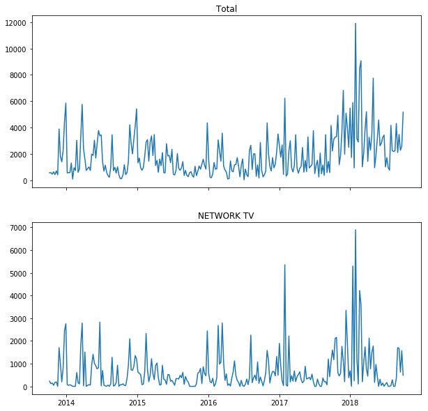

```python
# make a visual comparison of the weekly average Netflix ad spend data.
dimensions = (10, 10)
fig, (ax1, ax2) = plt.subplots(2, figsize = dimensions, sharex = 'all')

ax1.plot(Netflixweeklydata.index, Netflixweeklydata['TOTAL'])
ax2.plot(Netflixweeklydata.index, Netflixweeklydata['NETWORK TV'])

ax1.title.set_text('Total')
ax2.title.set_text('NETWORK TV')

plt.show()
```

Make a correlation test between the total Netflix ad spend and average Google trends data. According to the result, these two factors are correlated at a very small level. To get a proper correlation, we make this data stationary.

```python
# perform correlation test
Netflixweeklydata['TOTAL'].corr(Netflixweeklydata['value'])
# According to the result, these two factors are correlated at a very small level.
# We need to convert the data to stationary format for time series analysis.
```

```
0.07931662612588285
```

Calculate one day differences in `TOTAL` and store the values in a column called `TOTALdiff`. Also calculate one day differences in `value` and store the values in a column called `valuediff`.

```python
# calculate one day differences for Google search interest and ads spend.
Netflixweeklydata['TOTALdiff'] = Netflixweeklydata['TOTAL'].diff(1)
Netflixweeklydata['valuediff'] = Netflixweeklydata['value'].diff(1)
```

```python
# calculate the correlation
Netflixweeklydata['TOTALdiff'].corr(Netflixweeklydata['valuediff'])
```

```
0.18058165833278841
```

```python
Netflixweeklydata.to_csv('adspend.googletrends.weekly.csv')
```

### Section 4.2 Granger Causality and Shifting

```python
# read in data
adspend_trends = pd.read_csv('adspend.googletrends.weekly.csv', parse_dates = ['FIXED TIME'])
```

```python
# set fixed time as index
adspend_trends.set_index('FIXED TIME', inplace = True)
```

```python
list(adspend_trends)
```

```
['CABLE TV',
 'MAGAZINES',
 'NAT SPOT RADIO',
 'NATL NEWSP',
 'NETWORK RADIO',
 'NETWORK TV',
 'NEWSPAPER',
 'OUTDOOR',
 'SPOT TV',
 'SUNDAY MAGS',
 'SYNDICATION',
 'TOTAL',
 'Unnamed: 0',
 'value',
 'onediffvalue',
 'TOTALdiff',
 'valuediff']
```

```python
# remove unknown variables we made and inspect the column names again
adspend_trends = adspend_trends.drop(columns = ['onediffvalue', 'Unnamed: 0', 'TOTALdiff', 'valuediff'])
list(adspend_trends)
```

```
['CABLE TV',
 'MAGAZINES',
 'NAT SPOT RADIO',
 'NATL NEWSP',
 'NETWORK RADIO',
 'NETWORK TV',
 'NEWSPAPER',
 'OUTDOOR',
 'SPOT TV',
 'SUNDAY MAGS',
 'SYNDICATION',
 'TOTAL',
 'value']
```

```python
# use ADF to check the significance of stationarity
for acolumn in list(adspend_trends):
    adf_result = stattools.adfuller(adspend_trends[acolumn])
    print(adf_result[1])
```

```
4.944569609526588e-09
0.06237188986361679
0.6888967165130822
0.5507690801310768
0.9967319472189904
5.200387873510148e-06
0.09667874305370416
0.7976617760666814
0.34853519025821755
4.858038849581863e-29
0.2744078405823607
0.24171083022075313
0.05407759564271027
```

```python
adspend_trends_diff = pd.DataFrame()
```

```python
# calculate one day difference to see if we can get a stationary dataset
for acolumn in list(adspend_trends):
    columnnames = "%s_diff" % (acolumn)
    adspend_trends_diff[columnnames] = adspend_trends[acolumn].diff(1)
adspend_trends_diff.head()
```

| FIXED TIME | CABLE TV_diff | MAGAZINES_diff | NAT SPOT RADIO_diff | NATL NEWSP_diff | NETWORK RADIO_diff | NETWORK TV_diff | NEWSPAPER_diff | OUTDOOR_diff | SPOT TV_diff | SUNDAY MAGS_diff | SYNDICATION_diff | TOTAL_diff | value_diff |
| --- | --- | --- | --- | --- | --- | --- | --- | --- | --- | --- | --- | --- | --- |
| 2013-10-07 | NaN | NaN | NaN | NaN | NaN | NaN | NaN | NaN | NaN | NaN | NaN | NaN | NaN |
| 2013-10-14 | -33.3 | 0.0 | 0.0 | 0.0 | 0.0 | -105.7 | 0.0 | 0.0 | -10.1 | 0.0 | 150.3 | 1.2 | -380.308772 |
| 2013-10-21 | -7.2 | 0.0 | 0.0 | 0.0 | 0.0 | 28.6 | 0.0 | 0.0 | 0.6 | 0.0 | -134.4 | -112.4 | -618.494848 |
| 2013-10-28 | -10.4 | 0.0 | 0.0 | 0.0 | 0.0 | -101.1 | 0.0 | 233.0 | 11.2 | 0.0 | 47.0 | 179.8 | -747.196074 |
| 2013-11-04 | 9.3 | 0.0 | 0.0 | 0.0 | 0.0 | 131.2 | 0.0 | -233.0 | -6.4 | 0.0 | -110.8 | -209.8 | 462.095539 |

```python
for acolumn in list(adspend_trends_diff):
    adf_result = stattools.adfuller(adspend_trends_diff[acolumn].iloc[1:])
    print(adf_result[1])
```

```
2.737565394693417e-16
2.834615515519561e-14
8.44449296505387e-15
5.2624941219073705e-12
6.799586104486564e-06
4.097629531847151e-13
2.9107116033648535e-12
1.3630246836291944e-15
3.5528864600703405e-20
1.507821040229618e-13
1.8385816673648825e-17
7.158438380058312e-05
1.904983788426432e-13
```

```python
list(adspend_trends_diff)
```

```
['CABLE TV_diff',
 'MAGAZINES_diff',
 'NAT SPOT RADIO_diff',
 'NATL NEWSP_diff',
 'NETWORK RADIO_diff',
 'NETWORK TV_diff',
 'NEWSPAPER_diff',
 'OUTDOOR_diff',
 'SPOT TV_diff',
 'SUNDAY MAGS_diff',
 'SYNDICATION_diff',
 'TOTAL_diff',
 'value_diff']
```

```python
# calculate correlation between ads spends variables and Google search interests
correlationlist = []
for acolumn in list(adspend_trends_diff):
    if "value" not in acolumn:
        corr = adspend_trends_diff[acolumn].corr(adspend_trends_diff['value_diff'])
        print(acolumn, corr)
        correlationlist.append(corr)
```

```
CABLE TV_diff 0.2203641011484586
MAGAZINES_diff 0.05606900447146863
NAT SPOT RADIO_diff 0.02480378803853413
NATL NEWSP_diff 0.004636281702527561
NETWORK RADIO_diff -0.014175420952063408
NETWORK TV_diff 0.09689017500866812
NEWSPAPER_diff 0.14791680031854618
OUTDOOR_diff 0.09041040738031347
SPOT TV_diff 0.011802221229822218
SUNDAY MAGS_diff 0.04533792349282706
SYNDICATION_diff 0.12708521821198435
TOTAL_diff 0.1805816583327881
```

```python
# calculate the mean of these correlations.
np.mean(correlationlist)
```

```
0.08264351319865625
```

```python
# calculate the correlation again by using the original data.
correlationlist = []
for acolumn in list(adspend_trends):
    if "value" not in acolumn:
        corr = adspend_trends[acolumn].corr(adspend_trends['value'])
        print(acolumn, corr)
        correlationlist.append(corr)
```

```
CABLE TV 0.21732364780401534
MAGAZINES 0.04282481664567579
NAT SPOT RADIO 0.003628544658318102
NATL NEWSP -0.07741452486981847
NETWORK RADIO -0.03582219339670275
NETWORK TV 0.04137759675561025
NEWSPAPER 0.035156521348975484
OUTDOOR -0.0883332173235734
SPOT TV -0.1230979007347311
SUNDAY MAGS -0.017685645562027594
SYNDICATION 0.4945035319256308
TOTAL 0.0793166261258828
```

```python
np.mean(correlationlist)
```

```
0.047648150281437936
```

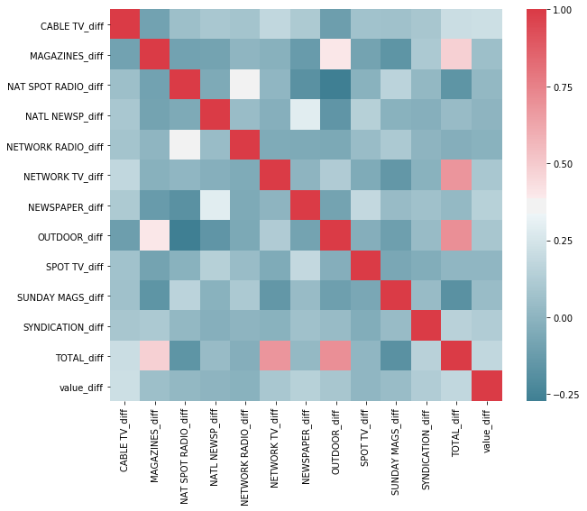

```python
# generate heatmap for correlation
f, ax = plt.subplots(figsize = (10, 8))
corr = adspend_trends_diff.corr()
sns.heatmap(corr, mask = np.zeros_like(corr, dtype = np.bool),
            cmap = sns.diverging_palette(220, 10, as_cmap = True),
            square = True, ax = ax)
plt.show()
```

```python
# perform granger causality test
# set the measurement period
numofweeks = 12
significantlags = []
for acolumn in list(adspend_trends_diff):
    if 'value' not in acolumn:
        testframe = adspend_trends_diff[['value_diff', acolumn]]
        testframe = testframe.iloc[1:]
        results = stattools.grangercausalitytests(testframe, numofweeks, verbose = False)
        for week in range(1, numofweeks + 1):
            # set level of significance.
            if results[week][0]['params_ftest'][1] < 0.05:
                print('%s is significnat at %s weeks' % (acolumn, week))
                significantlags.append(week)
```

```
CABLE TV_diff is significnat at 1 weeks
NAT SPOT RADIO_diff is significnat at 1 weeks
NAT SPOT RADIO_diff is significnat at 3 weeks
NAT SPOT RADIO_diff is significnat at 4 weeks
NAT SPOT RADIO_diff is significnat at 5 weeks
NAT SPOT RADIO_diff is significnat at 6 weeks
NAT SPOT RADIO_diff is significnat at 7 weeks
NAT SPOT RADIO_diff is significnat at 8 weeks
NAT SPOT RADIO_diff is significnat at 9 weeks
NAT SPOT RADIO_diff is significnat at 10 weeks
NAT SPOT RADIO_diff is significnat at 11 weeks
NAT SPOT RADIO_diff is significnat at 12 weeks
NETWORK RADIO_diff is significnat at 3 weeks
NETWORK RADIO_diff is significnat at 4 weeks
NETWORK RADIO_diff is significnat at 5 weeks
NETWORK RADIO_diff is significnat at 6 weeks
NETWORK RADIO_diff is significnat at 7 weeks
NETWORK RADIO_diff is significnat at 8 weeks
NETWORK RADIO_diff is significnat at 10 weeks
OUTDOOR_diff is significnat at 2 weeks
OUTDOOR_diff is significnat at 3 weeks
OUTDOOR_diff is significnat at 5 weeks
SUNDAY MAGS_diff is significnat at 2 weeks
SUNDAY MAGS_diff is significnat at 3 weeks
SUNDAY MAGS_diff is significnat at 4 weeks
SUNDAY MAGS_diff is significnat at 5 weeks
SUNDAY MAGS_diff is significnat at 6 weeks
SUNDAY MAGS_diff is significnat at 7 weeks
SUNDAY MAGS_diff is significnat at 8 weeks
SUNDAY MAGS_diff is significnat at 9 weeks
SUNDAY MAGS_diff is significnat at 10 weeks
SUNDAY MAGS_diff is significnat at 11 weeks
SUNDAY MAGS_diff is significnat at 12 weeks
SYNDICATION_diff is significnat at 4 weeks
SYNDICATION_diff is significnat at 5 weeks
SYNDICATION_diff is significnat at 11 weeks
SYNDICATION_diff is significnat at 12 weeks
TOTAL_diff is significnat at 5 weeks
TOTAL_diff is significnat at 6 weeks
```

**Do any advertising expenditures drive Google search interest?**

Yes, I think `CABLE TV` and `NEWSPAPER` could drive the Google search interest. Moreover, `NAT SPOT RADIO`, `NETWORK RADIO`, and `SYNDICATION` also have long term effect on Google search interest. According to the correlation test between ad spend difference and Google search interest difference, we could find `CABLE TV` and `NEWSPAPER` have the highest positive correlation with the Google search interest, which suggests increasing the spend on these two categories might also increase the Google search interest. `CABLE TV` and `NEWSPAPER` are also effective approaches to advertise Netflix. As the most significant competitor of cable tv, Netflix could show its benefits through a direct comparison on TV.

The Granger causality test couldn't tell correlation directly; however, it indicates the significance of lags, which means the advertising expenditures are still able to drive search interest after seeing the ads for N weeks.

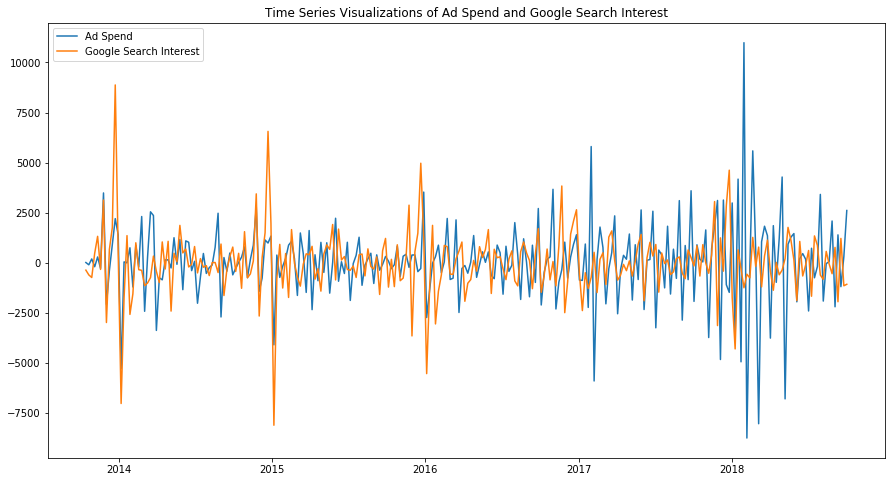

```python
fig, ax = pyplot.subplots(figsize=(15,8))

ax.plot(adspend_trends_diff.index, adspend_trends_diff['TOTAL_diff'])
ax.plot(adspend_trends_diff.index, adspend_trends_diff['value_diff'])

ax.title.set_text('Time Series Visualizations of Ad Spend and Google Search Interest')
ax.legend(('Ad Spend','Google Search Interest'))

plt.show()
```

**Create a time series visualizations that overlay both ad spend and Google search interest, to see if they visually align.**

#### Process data for modeling dataset

```python
# The most common lags in the list is 5 weeks.
mode(significantlags)
```

```
5
```

```python
modelingdataset = adspend_trends_diff
```

```python
modelingdataset.tail()
```

| FIXED TIME | CABLE TV_diff | MAGAZINES_diff | NAT SPOT RADIO_diff | NATL NEWSP_diff | NETWORK RADIO_diff | NETWORK TV_diff | NEWSPAPER_diff | OUTDOOR_diff | SPOT TV_diff | SUNDAY MAGS_diff | SYNDICATION_diff | TOTAL_diff | value_diff |
| --- | --- | --- | --- | --- | --- | --- | --- | --- | --- | --- | --- | --- | --- |
| 2018-09-03 | -220.6 | -645.5 | 49.3 | 0.0 | -71.7 | 1342.4 | -39.3 | -2511.7 | -114.9 | 0.0 | 0.0 | -2212.0 | 757.374014 |
| 2018-09-10 | -18.3 | 782.7 | 0.0 | 727.9 | 0.0 | -28.2 | -28.5 | 0.0 | -51.9 | 0.0 | 0.0 | 1383.7 | -1960.312593 |
| 2018-09-17 | 187.1 | -259.4 | 0.0 | -94.7 | 0.0 | -1051.6 | -7.8 | 0.0 | 14.0 | 0.0 | 7.3 | -1205.2 | 1205.581802 |
| 2018-09-24 | -180.5 | -98.6 | 0.0 | -595.5 | 0.0 | 943.4 | 2.7 | 0.0 | 162.2 | 0.0 | 56.7 | 290.4 | -1161.818662 |
| 2018-10-01 | 59.1 | 470.5 | -50.7 | 416.2 | 0.0 | -1078.4 | 95.6 | 2763.9 | -11.3 | 0.0 | -64.0 | 2600.7 | -1087.065425 |

```python
# created a 5-week lagged version of data
# attach 5 more weeks to the end of dataframe
date = pd.to_datetime('2018-10-08')
modelingdataset.loc[date] = np.nan
```

```python
date = pd.to_datetime('2018-10-15')
modelingdataset.loc[date] = np.nan
```

```python
date = pd.to_datetime('2018-10-22')
modelingdataset.loc[date] = np.nan
```

```python
date = pd.to_datetime('2018-10-29')
modelingdataset.loc[date] = np.nan
```

```python
date = pd.to_datetime('2018-11-05')
modelingdataset.loc[date] = np.nan
```

```python
modelingdataset.tail()
```

| FIXED TIME | CABLE TV_diff | MAGAZINES_diff | NAT SPOT RADIO_diff | NATL NEWSP_diff | NETWORK RADIO_diff | NETWORK TV_diff | NEWSPAPER_diff | OUTDOOR_diff | SPOT TV_diff | SUNDAY MAGS_diff | SYNDICATION_diff | TOTAL_diff | value_diff |
| --- | --- | --- | --- | --- | --- | --- | --- | --- | --- | --- | --- | --- | --- |
| 2018-10-08 | NaN | NaN | NaN | NaN | NaN | NaN | NaN | NaN | NaN | NaN | NaN | NaN | NaN |
| 2018-10-15 | NaN | NaN | NaN | NaN | NaN | NaN | NaN | NaN | NaN | NaN | NaN | NaN | NaN |
| 2018-10-22 | NaN | NaN | NaN | NaN | NaN | NaN | NaN | NaN | NaN | NaN | NaN | NaN | NaN |
| 2018-10-29 | NaN | NaN | NaN | NaN | NaN | NaN | NaN | NaN | NaN | NaN | NaN | NaN | NaN |
| 2018-11-05 | NaN | NaN | NaN | NaN | NaN | NaN | NaN | NaN | NaN | NaN | NaN | NaN | NaN |

```python
# shift the column down by 5 rows.
for acolumn in list(modelingdataset):
    if 'value' not in acolumn:
        # get lag up to 5
        for alag in range(1,6):
            columnname = '%s_lag%s' % (acolumn, alag)
            modelingdataset[columnname] = modelingdataset[acolumn].shift(alag)
```

```python
# sort the dataset by the name of column names
modelingdataset.sort_index(axis=1, inplace = True)
modelingdataset.head()
```

| FIXED TIME | CABLE TV_diff | CABLE TV_diff_lag1 | CABLE TV_diff_lag2 | CABLE TV_diff_lag3 | CABLE TV_diff_lag4 | CABLE TV_diff_lag5 | MAGAZINES_diff | MAGAZINES_diff_lag1 | MAGAZINES_diff_lag2 | MAGAZINES_diff_lag3 | ... | SYNDICATION_diff_lag3 | SYNDICATION_diff_lag4 | SYNDICATION_diff_lag5 | TOTAL_diff | TOTAL_diff_lag1 | TOTAL_diff_lag2 | TOTAL_diff_lag3 | TOTAL_diff_lag4 | TOTAL_diff_lag5 | value_diff |
| --- | --- | --- | --- | --- | --- | --- | --- | --- | --- | --- | --- | --- | --- | --- | --- | --- | --- | --- | --- | --- | --- |
| 2013-10-07 | NaN | NaN | NaN | NaN | NaN | NaN | NaN | NaN | NaN | NaN | ... | NaN | NaN | NaN | NaN | NaN | NaN | NaN | NaN | NaN | NaN |
| 2013-10-14 | -33.3 | NaN | NaN | NaN | NaN | NaN | 0.0 | NaN | NaN | NaN | ... | NaN | NaN | NaN | 1.2 | NaN | NaN | NaN | NaN | NaN | -380.308772 |
| 2013-10-21 | -7.2 | -33.3 | NaN | NaN | NaN | NaN | 0.0 | 0.0 | NaN | NaN | ... | NaN | NaN | NaN | -112.4 | 1.2 | NaN | NaN | NaN | NaN | -618.494848 |
| 2013-10-28 | -10.4 | -7.2 | -33.3 | NaN | NaN | NaN | 0.0 | 0.0 | 0.0 | NaN | ... | NaN | NaN | NaN | 179.8 | -112.4 | 1.2 | NaN | NaN | NaN | -747.196074 |
| 2013-11-04 | 9.3 | -10.4 | -7.2 | -33.3 | NaN | NaN | 0.0 | 0.0 | 0.0 | 0.0 | ... | 150.3 | NaN | NaN | -209.8 | 179.8 | -112.4 | 1.2 | NaN | NaN | 462.095539 |

5 rows × 73 columns

```python
modelingdataset.to_csv('google_adspend_differenced_lagged_fordatarobot.csv')
```

### Section 5. Advanced Time Series Analysis Forecasting

In section 5, I

1. forcasted the Google search interests through neural network
2. forcasted the Google search interests through lassolarscv
3. compared the results

### Section 5.1 Neural Network

```python
# load final modeling data
alldata = pd.read_csv('google_adspend_differenced_lagged_fordatarobot.csv')
```

```python
# drop rows contain empty values
alldata = alldata.iloc[6:]
alldata = alldata.iloc[:-5]
```

```python
alldata['FIXED TIME'] = pd.to_datetime((alldata['FIXED TIME']))
```

Perform neural network modeling based on the github instructions.

```python
# Gradient descent algorithms perform better if the variables are wihtin range [-1, 1].
# The `value_diff` variable is mixmax scaled to bound the tranformed variable within [-1,1].
scaler = MinMaxScaler(feature_range=(-1, 1))
alldata['scaled_value_diff'] = scaler.fit_transform(np.array(alldata['value_diff']).reshape(-1, 1))
```

```python
# split data in two parts - train set and validation set
# The neural network is trained on the train set.
# This means computation of the loss function, back propagation and weights updated by a gradient descent algorithm is done on the train set.
split_date = datetime.datetime(year=2017, month=11, day=10, hour=0)
df_train = alldata.loc[alldata['FIXED TIME']<split_date]
df_val = alldata.loc[alldata['FIXED TIME']>=split_date]
print('Shape of train:', df_train.shape)
print('Shape of test:', df_val.shape)
```

```
Shape of train: (208, 75)
Shape of test: (47, 75)
```

```python
# reset index
df_train.reset_index(drop=True, inplace=True)
df_val.reset_index(drop=True, inplace=True)
```

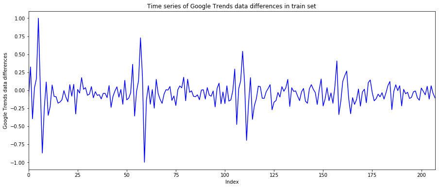

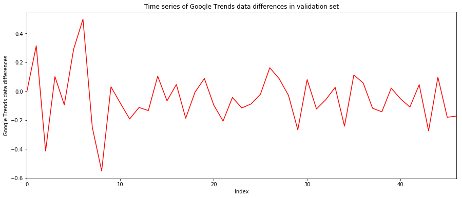

```python
# plot train times series of the standardized value_diff
plt.figure(figsize=(15, 6))
g = sns.tsplot(df_train['scaled_value_diff'], color='b')
g.set_title('Time series of Google Trends data differences in train set')
g.set_xlabel('Index')
g.set_ylabel('Google Trends data differences')

# plot validation times series of the standardized value_diff
plt.figure(figsize=(15, 6))
g = sns.tsplot(df_val['scaled_value_diff'], color='r')
g.set_title('Time series of Google Trends data differences in validation set')
g.set_xlabel('Index')
g.set_ylabel('Google Trends data differences')

plt.show()
```

```python
def makeXy(ts, nb_timesteps):
    X = []
    y = []
    for i in range(nb_timesteps, ts.shape[0]):
        X.append(list(ts.loc[i-nb_timesteps:i-1]))
        y.append(ts.loc[i])
    X, y = np.array(X), np.array(y)
    return X, y
```

```python
# generate regressors (X) and target variable (y) for train and validation sets
X_train, y_train = makeXy(df_train['scaled_value_diff'], 7)
print('Shape of train arrays:', X_train.shape, y_train.shape)
```

```
Shape of train arrays: (201, 7) (201,)
```

```python
X_val, y_val = makeXy(df_val['scaled_value_diff'], 7)
print('Shape of validation arrays:', X_val.shape, y_val.shape)
```

```
Shape of validation arrays: (40, 7) (40,)
```

```python
# initialize model
model = Sequential()
model.add(Dense(7, activation='relu', kernel_initializer='uniform', input_shape=(7,)))
# training with noise
layer = GaussianNoise(0.1)
model.add(GaussianNoise(0.01, input_shape=(620,)))
model.add(Dense(16, kernel_initializer='uniform', activation='relu'))
model.add(Dense(1, kernel_initializer='uniform', activation='sigmoid'))
```

```
WARNING:tensorflow:From /anaconda3/lib/python3.6/site-packages/tensorflow/python/framework/op_def_library.py:263: colocate_with (from tensorflow.python.framework.ops) is deprecated and will be removed in a future version.
Instructions for updating:
Colocations handled automatically by placer.
```

```python
# compile the model
model.compile(loss='binary_crossentropy',
              optimizer='adam',
              metrics=['accuracy'])
```

```python
model.fit(x=X_train, y=y_train, batch_size=201, epochs=100, verbose=1, validation_data=(X_val, y_val), shuffle=True)
```

```
WARNING:tensorflow:From /anaconda3/lib/python3.6/site-packages/tensorflow/python/ops/math_ops.py:3066: to_int32 (from tensorflow.python.ops.math_ops) is deprecated and will be removed in a future version.
Instructions for updating:
Use tf.cast instead.
```

```
Train on 201 samples, validate on 40 samples
```

```
<keras.callbacks.History at 0x1c3166fc88>
```

```python
# predict the results
preds = model.predict(X_val)
```

```python
# calculate R^2
r2 = r2_score(df_val['scaled_value_diff'].loc[7:], preds)
print('R-squared for the validation set:', round(r2,4))
```

```
R-squared for the validation set: -9.7842
```

### Section 5.2 LassoLarsCV

Applying LassoLarsCV work from class

```python
alldata.set_index(alldata['FIXED TIME'], inplace=True)
alldata = alldata.drop(columns=['FIXED TIME'])
```

```python
listofallpredictors = []
for i in list(alldata):
    if "value" not in i:
        listofallpredictors.append(i)
```

```python
predictors = alldata[listofallpredictors]
```

```python
target = alldata['value_diff']
```

```python
pred_train, pred_test, tar_train, tar_test = train_test_split(predictors, target, test_size=.3, random_state=123)
```

```python
model = LassoLarsCV(cv=10, precompute=False)
```

```python
model = model.fit(pred_train.values, tar_train.values)
```

```python
predictors_model = pd.DataFrame(listofallpredictors)
predictors_model.columns = ['label']
predictors_model['coeff'] = model.coef_
```

```python
for index, row in predictors_model.iterrows():
    if row['coeff'] > 0:
        print(row.values)
```

```
['CABLE TV_diff' 0.1285734995019148]
['CABLE TV_diff_lag1' 0.15987756252672494]
['NAT SPOT RADIO_diff_lag1' 0.8078840763738762]
['NETWORK RADIO_diff_lag1' 0.06786399492262714]
['NETWORK TV_diff_lag5' 0.1336582158383376]
['NEWSPAPER_diff' 0.053342876501953115]
['SUNDAY MAGS_diff_lag3' 3.8581864776861896]
['SYNDICATION_diff' 0.2710473033753247]
['TOTAL_diff' 0.05915094829297049]
```

```python
test_error = mean_squared_error(tar_test, model.predict(pred_test))
print('test data MSE')
print(test_error)
```

```
test data MSE
2651567.986036804
```

```python
rsquared_test = model.score(pred_test, tar_test)
print('test data r-square')
print(rsquared_test)
```

```
test data r-square
-0.06699879197221481
```

**Assess the degree to which your advanced approach outperforms the methods taught in class.**

Both of my approaches are not a good fit for my data. The LassoLarsCV has R^2 as -0.067 and Neural Network has R^2 as -9.784. Negative R^2 indicates the fitted model is even worse than a straight line.